# fitbit analysis for CSEP project

Shelby Sturrock

09/03/2022

# Fitbit analysis

**Summary**

This script contains a few simplified figures for the CSEP 24 hour movement guideline proof of concept paper.

**Data processing** steps include:

1. First, **remove participant-days of data where “TotalTimeInBed” is 0**. Eliminating these records (n~500, need to confirm) also removes all participants-days with 0 total steps, 0 minutes of light physical activity and 1440 minutes of sedentary time. This step happens in the “fitbit-wrangling” file and the records are omitted from the TOP.
2. Second, **remove participant-days with less than 10 hours of wear time**. Minute-level data was identified as “non-wear time” if the current minute and the previous 9 minutes each had 0 steps, missing heart rate AND were flagged as having “sedentary” intensity. If these conditions are met, all 10 minutes are flagged as “non-wear time”. If at least one minute has >0 steps, non-sedentary intensity OR a heart rate value, none of the 10 minutes are flagged as non-wear time. Total non-wear minutes were then summed per participant and day, and days with > 840 minutes of non-wear time were excluded from analysis (n=3). This steps occurs within this script.
3. Third, **remove the first day of data (October 18, 2021)** because the mean number of non-wear minutes across participant was an order of magnitude higher than the second highest day (~650 minutes vs. ~62 minutes), which led to artificially low light PA, and sleep, but inflated sedentary time.

**Analysis includes:**

### Read in and format data

Read in data

```r
daily <- read.csv("daily-TOP-CSEP.csv")
str(daily$date)
```

```
##  chr [1:3533] "2021-10-19" "2021-10-22" "2021-10-23" "2021-10-24" ...
```

Make sure that the intervention variable and the weekday variables are formatted as factors where the intervention periods and weekdays are ordered correctly (pre, intervention, post; monday, tuesday, etc.)

```r
  daily$weekday<-factor(daily$weekday,
                        levels=c("Monday","Tuesday","Wednesday","Thursday","Friday","Saturday","Sunday"))
  daily$intervention<-factor(daily$intervention,levels=c("pre","intervention","post"))
  daily$date<-as.Date(daily$date)
  str(daily$weekday)
```

```
##  Factor w/ 7 levels "Monday","Tuesday",..: 2 5 6 7 1 3 4 5 6 7 ...
```

```r
  str(daily$intervention)
```

```
##  Factor w/ 3 levels "pre","intervention",..: 1 1 1 1 2 2 2 2 2 2 ...
```

Create person-day-level for plots. Currently, the “daily” dataframe has one row per person-day-article, so if someone engages with two different articles, they have two rows in the dataframe. I want a maximum of one row per person per day for data exploration.

```r
  dailyForPlots<-daily[!is.na(daily$totalMVPA),] %>% select(-title,-intervention_content,-featured_content,
                                                            -pubdate,-weekofpublish,
                                                            -type,-click,-engage,-clickInt,-engageInt)
  dailyForPlots<-distinct(dailyForPlots)
# tentative: remove particiapnt-days with less than 10 hours of wear time (so 14 hours or more of non-wear time)
  # 14 * 60 = 840 (840 minutes or more of non-wear time)
```

Explore total minutes of data contributed per particiant day. Should be ~1440 minutes

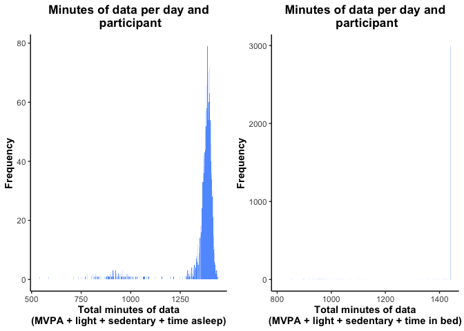

## MVPA

### Plot of minutes of MVPA per day over time

#### Trend over study period

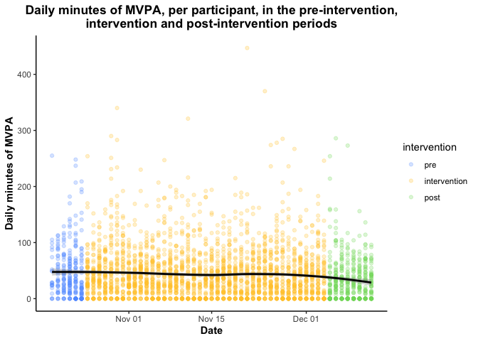

#### Trend before, during and after intervention

Largely stable over time, particularly during the intervention period. Slightly lower in post-period.

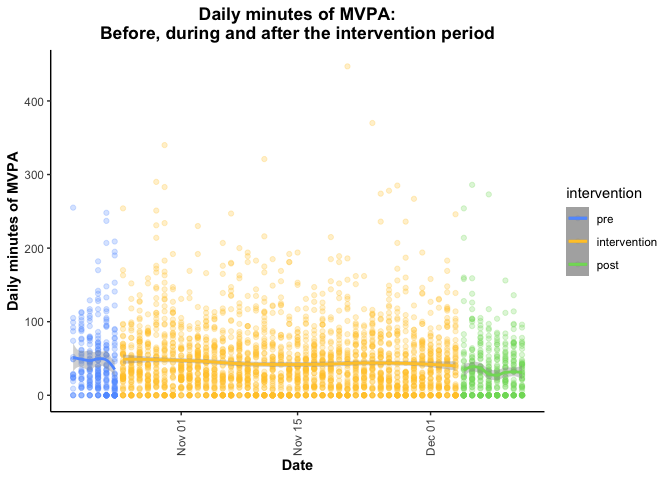

## LPA

#### Trend over study period

Slight downward trend in lightly active minutes over time (looks driven by post-period)

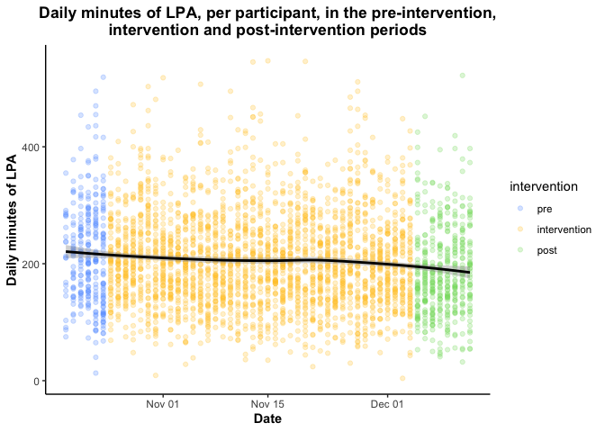

#### Trend before, during and after intervention

Largely stable over time, particularly during the intervention period. Slightly lower in post-period.

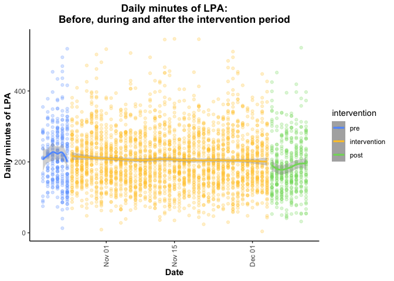

## Sedentary Behaviour

#### Trend over study period

Slight bow (highest at beginning and end) but more or less stable over time.

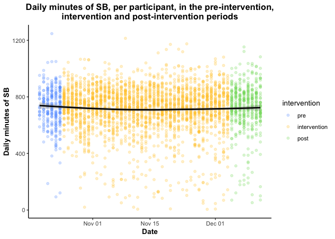

#### Trend before, during and after intervention

Sedentary time appeared to decrease slightly during the pre-period, otherwise stable over time.

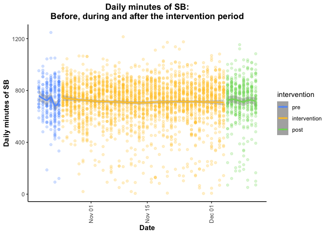

## Sleep

#### Trend over study period

Sleep appears to increase slightly over time.

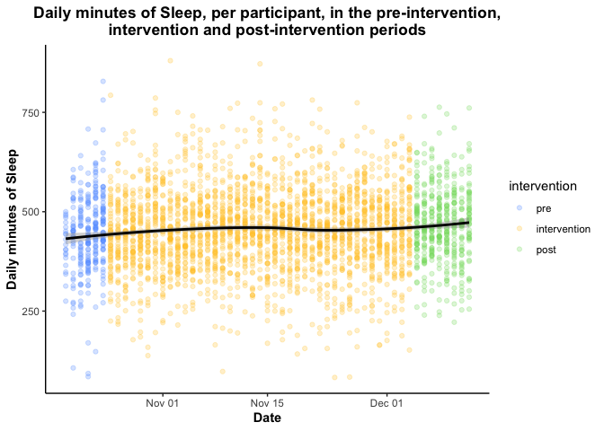

#### Trend before, during and after intervention

Fit a loess curve to each of the three periods. Appears that sleep increased during each period.

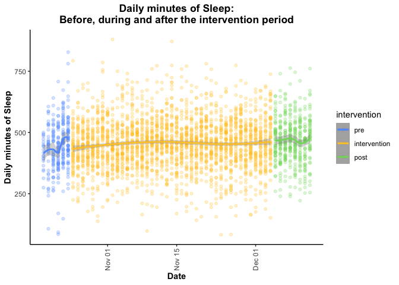

## High-level: All movement behaviours over time

Plot of all movement behaviours over time

```
## Before During  After
##   1156   9844   1772
```

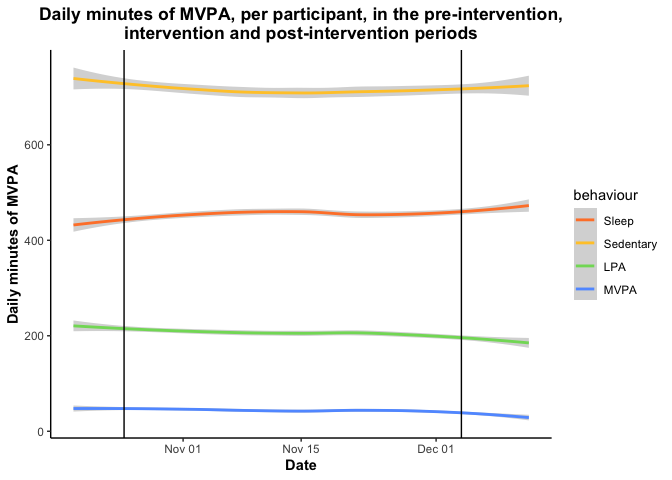

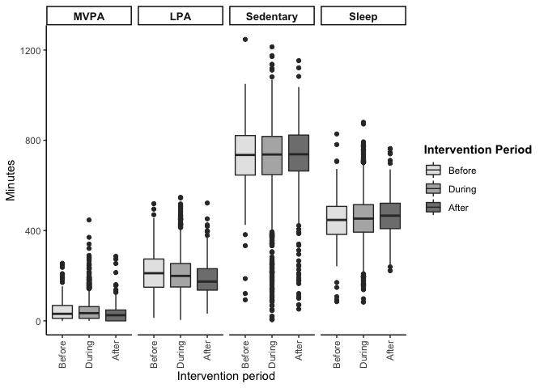

# Plots

## Boxplot - one panel per movement behaviour

#### MVPA

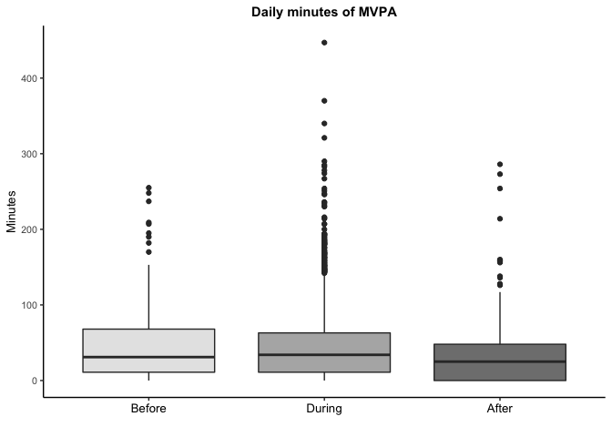

#### Lightly active minutes

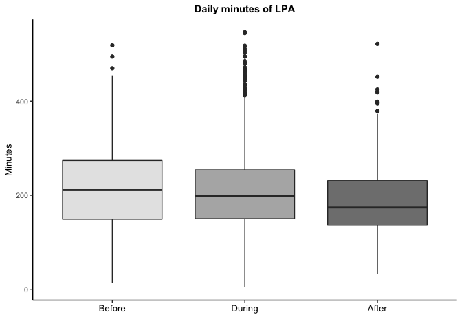

#### Sedentary time

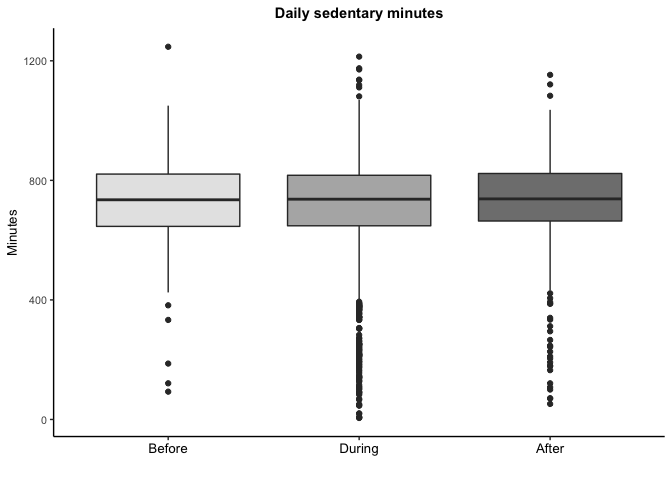

#### Sleep

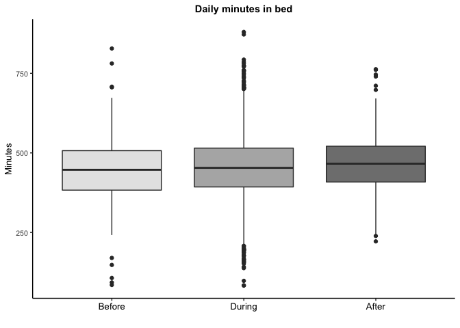

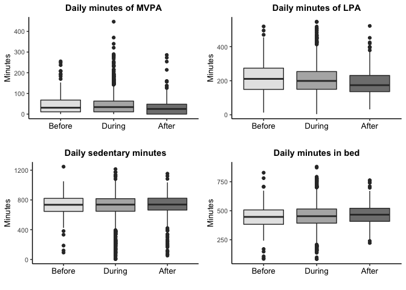

## Line Graph - with engagement and clicks overlayed

```r
# # MVPA
#   dailyForPlots$clickMVPA<-dailyForPlots$dayCountClickAny*(mean(dailyForPlots$totalMVPA)/mean(dailyForPlots$dayCountClickAny))
#   dailyForPlots$engageMVPA<-dailyForPlots$dayCountEngageAny*(mean(dailyForPlots$totalMVPA)/mean(dailyForPlots$dayCountEngageAny))
#
# # Lightly Active Minutes
#   dailyForPlots$clickLPA<-dailyForPlots$dayCountClickAny*
#                           (mean(dailyForPlots$LightlyActiveMinutes)/mean(dailyForPlots$dayCountClickAny))
#   dailyForPlots$engageLPA<-dailyForPlots$dayCountEngageAny*
#                            (mean(dailyForPlots$LightlyActiveMinutes)/mean(dailyForPlots$dayCountEngageAny))
#
# # Sedentary Behavior
#   dailyForPlots$clickSB<-dailyForPlots$dayCountClickAny*
#                           (mean(dailyForPlots$SedentaryMinutes)/mean(dailyForPlots$dayCountClickAny))
#   dailyForPlots$engageSB<-dailyForPlots$dayCountEngageAny*
#                           (mean(dailyForPlots$SedentaryMinutes)/mean(dailyForPlots$dayCountEngageAny))
#
# # Sleep
#   dailyForPlots$clickSleep<-dailyForPlots$dayCountClickAny*
#                             (mean(dailyForPlots$TotalTimeInBed)/mean(dailyForPlots$dayCountClickAny))
#   dailyForPlots$engageSleep<-dailyForPlots$dayCountEngageAny*
#                             (mean(dailyForPlots$TotalTimeInBed)/mean(dailyForPlots$dayCountEngageAny))
```

### Intervention clicks during intervention period

The following figures display trends in **clicks on intervention content compared to trends in each movement behaviour over the course of the intervention period**. The y axis on the left concerns the movement behaviour (colored lines) and the y axis on the right concerns daily clicks on intervention content (black line).

Generate click and engagement variables that are rescaled such that the mean = mean of the respective behaviour for plotting

```r
  dailyInt<-dailyForPlots[dailyForPlots$intervention=="intervention",]

# MVPA
  dailyInt$clickIntMVPA<-dailyInt$dayCountClickInt*
                               (mean(dailyInt$totalMVPA)/mean(dailyInt$dayCountClickInt))
  dailyInt$engageIntMVPA<-dailyInt$dayCountEngageInt*
                               (mean(dailyInt$totalMVPA)/mean(dailyInt$dayCountEngageInt))

# Lightly Active Minutes
  dailyInt$clickIntLPA<-dailyInt$dayCountClickInt*
                          (mean(dailyInt$LightlyActiveMinutes)/mean(dailyInt$dayCountClickInt))
  dailyInt$engageIntLPA<-dailyInt$dayCountEngageInt*
                           (mean(dailyInt$LightlyActiveMinutes)/mean(dailyInt$dayCountEngageInt))

# Sedentary Behavior
  dailyInt$clickIntSB<-dailyInt$dayCountClickInt*
                          (mean(dailyInt$SedentaryMinutes)/mean(dailyInt$dayCountClickInt))
  dailyInt$engageIntSB<-dailyInt$dayCountEngageInt*
                          (mean(dailyInt$SedentaryMinutes)/mean(dailyInt$dayCountEngageInt))

# Sleep
  dailyInt$clickIntSleep<-dailyInt$dayCountClickInt*
                            (mean(dailyInt$TotalTimeInBed)/mean(dailyInt$dayCountClickInt))
  dailyInt$engageIntSleep<-dailyInt$dayCountEngageInt*
                            (mean(dailyInt$TotalTimeInBed)/mean(dailyInt$dayCountEngageInt))
```

### Using LOESS smoother

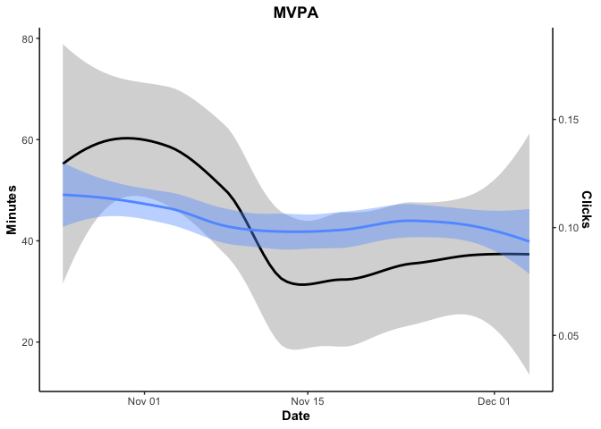

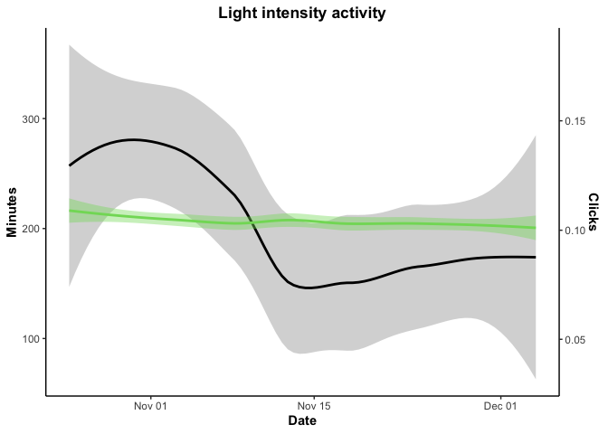

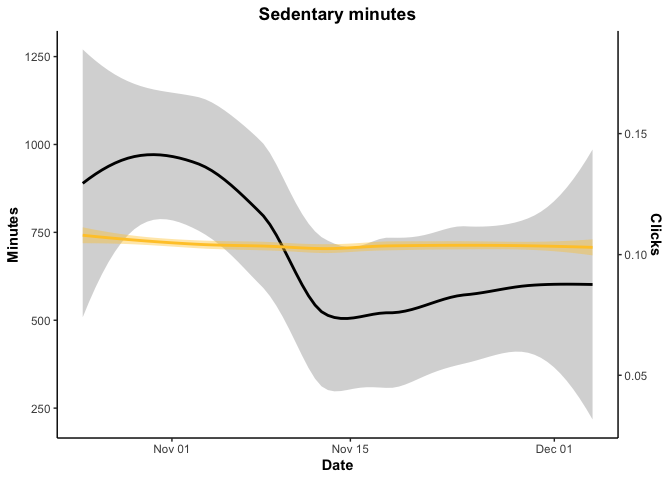

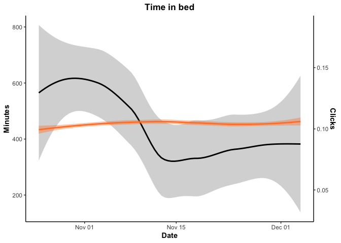

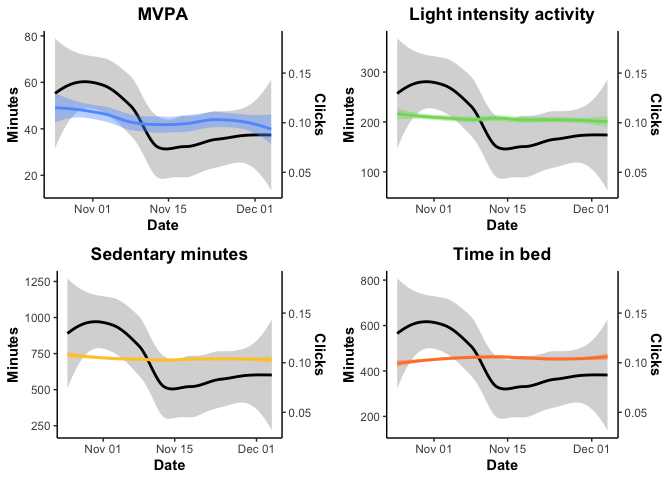

### Using multilevel models

Create a time variable (where Oct 18 = 1, Oct 19 = 2, etc.)

#### Clicks

1. plot to see what emerges when data is allowed to dictate the shape. *It looks as though there is at least 2 or 3 inflection points… requiring a third or fourth order factor*

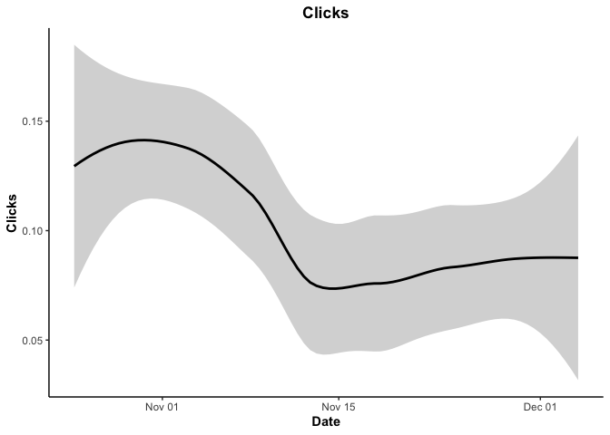

2. assess models of daily intervention clicks as a function of date/time with and without higher order time parameters.

```r
# linear, no higher order factors
  test<-lm(dayCountClickInt~nDate,data=dailyInt)
  summary(test)
```

```
##
## Call:
## lm(formula = dayCountClickInt ~ nDate, data = dailyInt)
##
## Residuals:
##     Min      1Q  Median      3Q     Max
## -0.1387 -0.1196 -0.1004 -0.0813  5.9221
##
## Coefficients:
##               Estimate Std. Error t value Pr(>|t|)
## (Intercept)  0.1404164  0.0162173   8.658  < 2e-16 ***
## nDate       -0.0017378  0.0006739  -2.579  0.00997 **
## ---
## Signif. codes:  0 '***' 0.001 '**' 0.01 '*' 0.05 '.' 0.1 ' ' 1
##
## Residual standard error: 0.3964 on 2459 degrees of freedom
## Multiple R-squared:  0.002697,   Adjusted R-squared:  0.002292
## F-statistic:  6.65 on 1 and 2459 DF,  p-value: 0.009971
```

```r
# linear + quadratic (nDate^2)
  test2<-lm(dayCountClickInt~nDate+I(nDate*nDate),data=dailyInt)
  summary(test2)
```

```
##
## Call:
## lm(formula = dayCountClickInt ~ nDate + I(nDate * nDate), data = dailyInt)
##
## Residuals:
##     Min      1Q  Median      3Q     Max
## -0.1566 -0.1154 -0.0910 -0.0842  5.9163
##
## Coefficients:
##                    Estimate Std. Error t value Pr(>|t|)
## (Intercept)       1.612e-01  2.509e-02   6.423 1.59e-10 ***
## nDate            -4.641e-03  2.763e-03  -1.680   0.0932 .
## I(nDate * nDate)  6.916e-05  6.385e-05   1.083   0.2788
## ---
## Signif. codes:  0 '***' 0.001 '**' 0.01 '*' 0.05 '.' 0.1 ' ' 1
##
## Residual standard error: 0.3964 on 2458 degrees of freedom
## Multiple R-squared:  0.003173,   Adjusted R-squared:  0.002362
## F-statistic: 3.912 on 2 and 2458 DF,  p-value: 0.02012
```

```r
# linear + cubic (nDate^3)
  test3<-lm(dayCountClickInt~poly(nDate,3),data=dailyInt)
  summary(test3)
```

```
##
## Call:
## lm(formula = dayCountClickInt ~ poly(nDate, 3), data = dailyInt)
##
## Residuals:
##     Min      1Q  Median      3Q     Max
## -0.1412 -0.1236 -0.0941 -0.0793  5.9184
##
## Coefficients:
##                 Estimate Std. Error t value Pr(>|t|)
## (Intercept)      0.10402    0.00799  13.019  < 2e-16 ***
## poly(nDate, 3)1 -1.02216    0.39637  -2.579  0.00997 **
## poly(nDate, 3)2  0.42937    0.39637   1.083  0.27880
## poly(nDate, 3)3  0.34264    0.39637   0.864  0.38744
## ---
## Signif. codes:  0 '***' 0.001 '**' 0.01 '*' 0.05 '.' 0.1 ' ' 1
##
## Residual standard error: 0.3964 on 2457 degrees of freedom
## Multiple R-squared:  0.003476,   Adjusted R-squared:  0.002259
## F-statistic: 2.857 on 3 and 2457 DF,  p-value: 0.03579
```

```r
# compare AIC for the four models
  extractAIC(test)
```

```
## [1]     2.000 -4552.894
```

```r
  extractAIC(test2)
```

```
## [1]     3.000 -4552.068
```

```r
  extractAIC(test3)
```

```
## [1]     4.000 -4550.817
```

3. models, with random intercept per participant

```r
  click<-lme4::lmer(dayCountClickInt~nDate+(1|Id),data=dailyInt)
```

4. generate predicted values

```r
  dailyInt$fit_click<-fitted(click)
```

5. plot predicted value of clicks

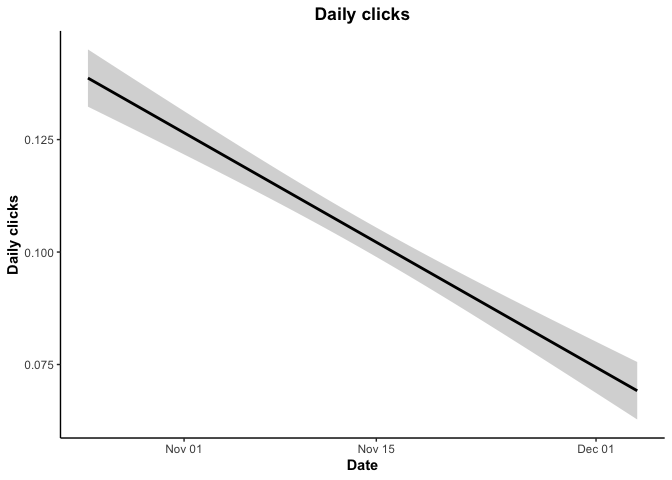

#### Engagement

1. plot to see what emerges when data is allowed to dictate the shape.

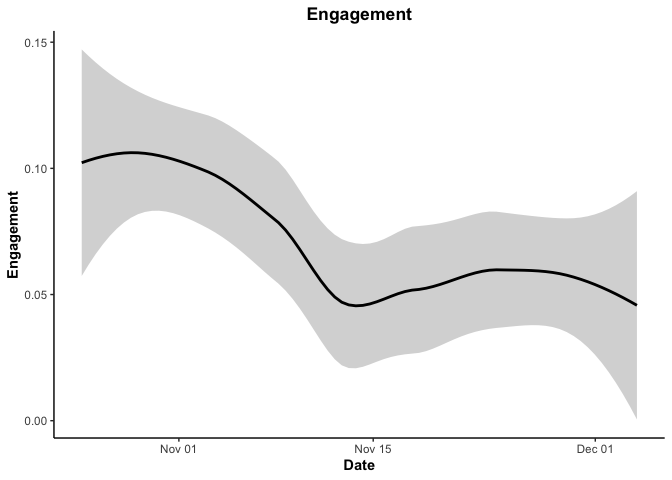

2. assess models of daily intervention engagement as a function of date/time with and without higher order time parameters.

```r
# linear, no higher order factors
  test<-lm(dayCountEngageInt~nDate,data=dailyInt)
  summary(test)
```

```
##
## Call:
## lm(formula = dayCountEngageInt ~ nDate, data = dailyInt)
##
## Residuals:
##     Min      1Q  Median      3Q     Max
## -0.1042 -0.0868 -0.0695 -0.0537  5.9510
##
## Coefficients:
##               Estimate Std. Error t value Pr(>|t|)
## (Intercept)  0.1057653  0.0131270   8.057 1.21e-15 ***
## nDate       -0.0015772  0.0005455  -2.892  0.00387 **
## ---
## Signif. codes:  0 '***' 0.001 '**' 0.01 '*' 0.05 '.' 0.1 ' ' 1
##
## Residual standard error: 0.3208 on 2459 degrees of freedom
## Multiple R-squared:  0.003389,   Adjusted R-squared:  0.002983
## F-statistic: 8.361 on 1 and 2459 DF,  p-value: 0.003867
```

```r
# linear + quadratic (nDate^2)
  test2<-lm(dayCountEngageInt~nDate+I(nDate*nDate),data=dailyInt)
  summary(test2)
```

```
##
## Call:
## lm(formula = dayCountEngageInt ~ nDate + I(nDate * nDate), data = dailyInt)
##
## Residuals:
##     Min      1Q  Median      3Q     Max
## -0.1185 -0.0835 -0.0619 -0.0546  5.9463
##
## Coefficients:
##                    Estimate Std. Error t value Pr(>|t|)
## (Intercept)       1.224e-01  2.031e-02   6.025 1.95e-09 ***
## nDate            -3.899e-03  2.237e-03  -1.743   0.0814 .
## I(nDate * nDate)  5.532e-05  5.168e-05   1.070   0.2845
## ---
## Signif. codes:  0 '***' 0.001 '**' 0.01 '*' 0.05 '.' 0.1 ' ' 1
##
## Residual standard error: 0.3208 on 2458 degrees of freedom
## Multiple R-squared:  0.003853,   Adjusted R-squared:  0.003043
## F-statistic: 4.754 on 2 and 2458 DF,  p-value: 0.008699
```

```r
# linear + cubic (nDate^3)
  test3<-lm(dayCountEngageInt~poly(nDate,3),data=dailyInt)
  summary(test3)
```

```
##
## Call:
## lm(formula = dayCountEngageInt ~ poly(nDate, 3), data = dailyInt)
##
## Residuals:
##     Min      1Q  Median      3Q     Max
## -0.1156 -0.0850 -0.0614 -0.0543  5.9467
##
## Coefficients:
##                  Estimate Std. Error t value Pr(>|t|)
## (Intercept)      0.072735   0.006468  11.245  < 2e-16 ***
## poly(nDate, 3)1 -0.927710   0.320890  -2.891  0.00387 **
## poly(nDate, 3)2  0.343442   0.320890   1.070  0.28460
## poly(nDate, 3)3  0.063484   0.320890   0.198  0.84319
## ---
## Signif. codes:  0 '***' 0.001 '**' 0.01 '*' 0.05 '.' 0.1 ' ' 1
##
## Residual standard error: 0.3209 on 2457 degrees of freedom
## Multiple R-squared:  0.003869,   Adjusted R-squared:  0.002653
## F-statistic: 3.181 on 3 and 2457 DF,  p-value: 0.02305
```

```r
# compare AIC for the four models
  extractAIC(test)
```

```
## [1]     2.000 -5593.446
```

```r
  extractAIC(test2)
```

```
## [1]     3.000 -5592.593
```

```r
  extractAIC(test3)
```

```
## [1]     4.000 -5590.632
```

3. models, with random intercept per participant

```r
  engage<-lme4::lmer(dayCountEngageInt~nDate+(1|Id),data=dailyInt)
```

4. generate predicted values

```r
  dailyInt$fit_engage<-fitted(engage)
```

5. plot predicted values of daily engagement over time

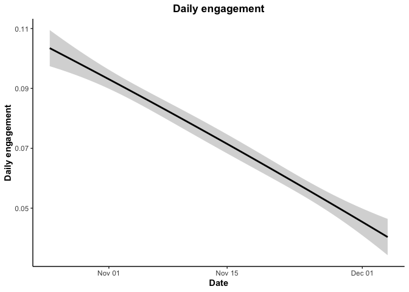

#### MVPA:

1. plot to see what emerges when data is allowed to dictate the shape.

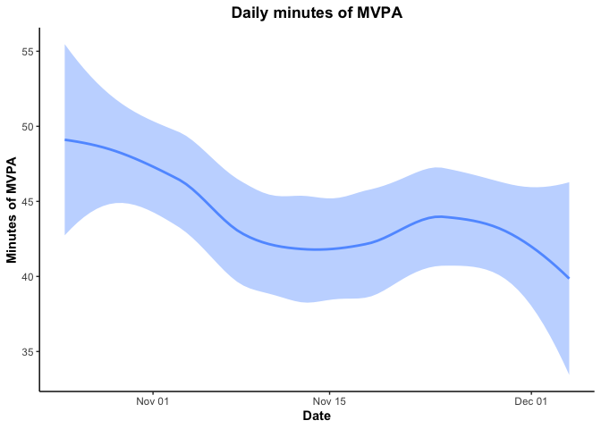

```r
# linear, no higher order factors
  test<-lm(totalMVPA~nDate,data=dailyInt)
  summary(test)
```

```
##
## Call:
## lm(formula = totalMVPA ~ nDate, data = dailyInt)
##
## Residuals:
##    Min     1Q Median     3Q    Max
## -47.75 -32.80 -10.73  18.52 403.84
##
## Coefficients:
##             Estimate Std. Error t value Pr(>|t|)
## (Intercept) 47.91702    1.86124  25.745   <2e-16 ***
## nDate       -0.16998    0.07734  -2.198   0.0281 *
## ---
## Signif. codes:  0 '***' 0.001 '**' 0.01 '*' 0.05 '.' 0.1 ' ' 1
##
## Residual standard error: 45.49 on 2459 degrees of freedom
## Multiple R-squared:  0.001961,   Adjusted R-squared:  0.001555
## F-statistic: 4.831 on 1 and 2459 DF,  p-value: 0.02805
```

```r
# linear + quadratic (nDate^2)
  test2<-lm(totalMVPA~nDate+I(nDate*nDate),data=dailyInt)
  summary(test2)
```

```
##
## Call:
## lm(formula = totalMVPA ~ nDate + I(nDate * nDate), data = dailyInt)
##
## Residuals:
##    Min     1Q Median     3Q    Max
## -49.59 -32.45 -10.62  18.40 404.49
##
## Coefficients:
##                   Estimate Std. Error t value Pr(>|t|)
## (Intercept)      50.054233   2.879489  17.383   <2e-16 ***
## nDate            -0.469165   0.317137  -1.479    0.139
## I(nDate * nDate)  0.007128   0.007328   0.973    0.331
## ---
## Signif. codes:  0 '***' 0.001 '**' 0.01 '*' 0.05 '.' 0.1 ' ' 1
##
## Residual standard error: 45.49 on 2458 degrees of freedom
## Multiple R-squared:  0.002345,   Adjusted R-squared:  0.001533
## F-statistic: 2.888 on 2 and 2458 DF,  p-value: 0.05585
```

```r
# linear + cubic (nDate^3)
  test3<-lm(totalMVPA~poly(nDate,3),data=dailyInt)
  summary(test3)
```

```
##
## Call:
## lm(formula = totalMVPA ~ poly(nDate, 3), data = dailyInt)
##
## Residuals:
##    Min     1Q Median     3Q    Max
## -50.79 -32.42 -10.88  18.68 403.91
##
## Coefficients:
##                 Estimate Std. Error t value Pr(>|t|)
## (Intercept)      44.3572     0.9171  48.365   <2e-16 ***
## poly(nDate, 3)1 -99.9831    45.4973  -2.198   0.0281 *
## poly(nDate, 3)2  44.2515    45.4973   0.973   0.3308
## poly(nDate, 3)3 -26.3536    45.4973  -0.579   0.5625
## ---
## Signif. codes:  0 '***' 0.001 '**' 0.01 '*' 0.05 '.' 0.1 ' ' 1
##
## Residual standard error: 45.5 on 2457 degrees of freedom
## Multiple R-squared:  0.002481,   Adjusted R-squared:  0.001263
## F-statistic: 2.037 on 3 and 2457 DF,  p-value: 0.1066
```

```r
# compare AIC for the four models
  extractAIC(test)
```

```
## [1]     2.00 18791.77
```

```r
  extractAIC(test2)
```

```
## [1]     3.00 18792.82
```

```r
  extractAIC(test3)
```

```
## [1]     4.00 18794.49
```

3. models, with random intercept per participant

```r
  mvpa<-lme4::lmer(totalMVPA~nDate+(1|Id),data=dailyInt)
```

4. generate predicted values

```r
  dailyInt$fit_mvpa<-fitted(mvpa)
```

5. rescale engagement and click data for plotting with MVPA

```r
  dailyInt$click_mvpa<-dailyInt$fit_click*
                               (mean(dailyInt$fit_mvpa)/mean(dailyInt$fit_click))
  dailyInt$engage_mvpa<-dailyInt$fit_engage*
                               (mean(dailyInt$fit_mvpa)/mean(dailyInt$fit_engage))
```

6. plot predicted values of MVPA over time + predicted values of intervention clicks

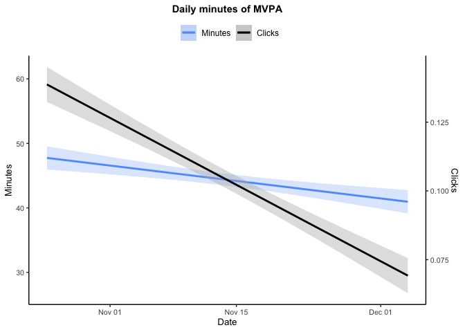

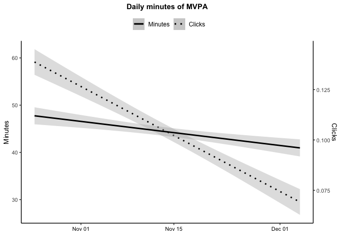

#### Lightly active minutes:

1. plot to see what emerges when data is allowed to dictate the shape.

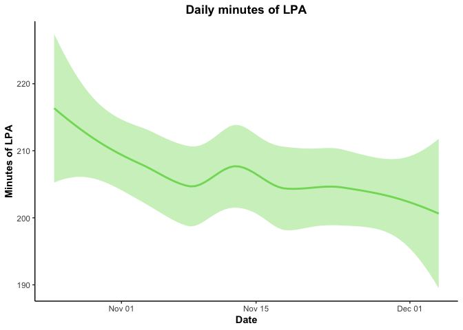

```r
# linear, no higher order factors
  test<-lm(LightlyActiveMinutes~nDate,data=dailyInt)
  summary(test)
```

```
##
## Call:
## lm(formula = LightlyActiveMinutes ~ nDate, data = dailyInt)
##
## Residuals:
##     Min      1Q  Median      3Q     Max
## -201.31  -56.69   -7.46   47.46  341.07
##
## Coefficients:
##             Estimate Std. Error t value Pr(>|t|)
## (Intercept) 212.1879     3.2366   65.56   <2e-16 ***
## nDate        -0.2689     0.1345   -2.00   0.0456 *
## ---
## Signif. codes:  0 '***' 0.001 '**' 0.01 '*' 0.05 '.' 0.1 ' ' 1
##
## Residual standard error: 79.11 on 2459 degrees of freedom
## Multiple R-squared:  0.001624,   Adjusted R-squared:  0.001218
## F-statistic: 3.999 on 1 and 2459 DF,  p-value: 0.04564
```

```r
# linear + quadratic (nDate^2)
  test2<-lm(LightlyActiveMinutes~nDate+I(nDate*nDate),data=dailyInt)
  summary(test2)
```

```
##
## Call:
## lm(formula = LightlyActiveMinutes ~ nDate + I(nDate * nDate),
##     data = dailyInt)
##
## Residuals:
##     Min      1Q  Median      3Q     Max
## -201.70  -57.02   -7.69   47.94  341.82
##
## Coefficients:
##                   Estimate Std. Error t value Pr(>|t|)
## (Intercept)      214.33475    5.00797  42.799   <2e-16 ***
## nDate             -0.56948    0.55156  -1.032    0.302
## I(nDate * nDate)   0.00716    0.01274   0.562    0.574
## ---
## Signif. codes:  0 '***' 0.001 '**' 0.01 '*' 0.05 '.' 0.1 ' ' 1
##
## Residual standard error: 79.12 on 2458 degrees of freedom
## Multiple R-squared:  0.001752,   Adjusted R-squared:  0.0009396
## F-statistic: 2.157 on 2 and 2458 DF,  p-value: 0.1159
```

```r
# linear + cubic (nDate^3)
  test3<-lm(LightlyActiveMinutes~poly(nDate,3),data=dailyInt)
  summary(test3)
```

```
##
## Call:
## lm(formula = LightlyActiveMinutes ~ poly(nDate, 3), data = dailyInt)
##
## Residuals:
##     Min      1Q  Median      3Q     Max
## -200.94  -56.52   -7.69   47.47  341.47
##
## Coefficients:
##                 Estimate Std. Error t value Pr(>|t|)
## (Intercept)      206.555      1.595 129.505   <2e-16 ***
## poly(nDate, 3)1 -158.193     79.124  -1.999   0.0457 *
## poly(nDate, 3)2   44.452     79.124   0.562   0.5743
## poly(nDate, 3)3  -62.432     79.124  -0.789   0.4302
## ---
## Signif. codes:  0 '***' 0.001 '**' 0.01 '*' 0.05 '.' 0.1 ' ' 1
##
## Residual standard error: 79.12 on 2457 degrees of freedom
## Multiple R-squared:  0.002005,   Adjusted R-squared:  0.0007862
## F-statistic: 1.645 on 3 and 2457 DF,  p-value: 0.1769
```

```r
# compare AIC for the four models
  extractAIC(test)
```

```
## [1]     2.00 21515.06
```

```r
  extractAIC(test2)
```

```
## [1]     3.00 21516.75
```

```r
  extractAIC(test3)
```

```
## [1]     4.00 21518.13
```

3. models, with random intercept per participant

```r
  LPA<-lme4::lmer(LightlyActiveMinutes~nDate+(1|Id),data=dailyInt)
```

4. generate predicted values

```r
  dailyInt$fit_LPA<-fitted(LPA)
```

5. rescale engagement and click data for plotting with LPA

```r
  dailyInt$click_LPA<-dailyInt$fit_click*
                               (mean(dailyInt$fit_LPA)/mean(dailyInt$fit_click))
  dailyInt$engage_LPA<-dailyInt$fit_engage*
                               (mean(dailyInt$fit_LPA)/mean(dailyInt$fit_engage))
```

6. plot predicted values LPA over time + predicted values of intervention clicks

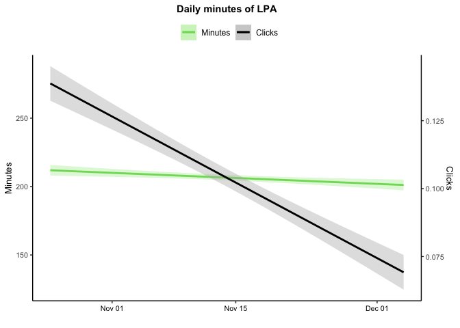

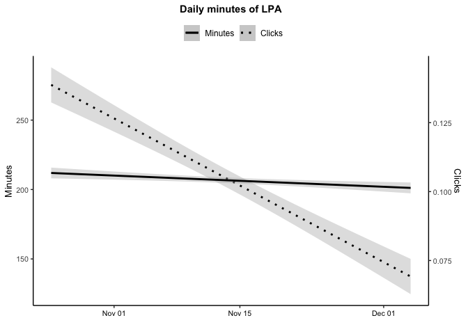